# Dplyr

Quantitative Methodology (UPF)

Jordi Mas Elias

https://www.jordimas.cat/

## Summary

- Pipe
- Row dplyr functions
- Column dplyr functions
- Transform variables

# Warm up

## R learning curve

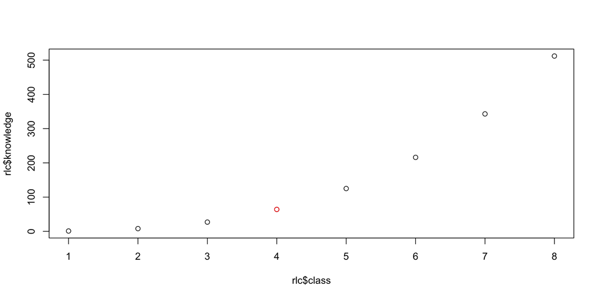

# Pipe

## Pipe

One function

```r
f(d$v)
f(d, v)
d |> f(v)
1:100 |>
   sample(4)
```

Various functions

```r
f1(f1(d, v1), v2)
d |>
  f1(v1) |>
  f2(v2)
```

## Pipe

Without pipe

```r
go_to_upf(take_transport(get_dressed(get_out_of_bed(wake_up(me,
time = "8:30"), side = "left"), pants = TRUE, shirt = TRUE),
bus = TRUE, metro = FALSE), mqi = FALSE, bar = TRUE)
```

With pipe

```r
me |>
  wake_up(time = "8:30") |>
  get_out_of_bed(side = "left") |>
  get_dressed(pants = TRUE, shirt = TRUE) |>
  take_transport(bus = TRUE, metro = FALSE) |>
  go_to_upf(mqi = FALSE, bar = TRUE)
```

Example taken from [here](https://twitter.com/hadleywickham/status/1359852563726819332?s=20&t=J8qesZb3u9EAwVKMYMgh1Q) and [here](https://evalsp21.classes.andrewheiss.com/projects/01_lab/slides/01_lab.html#116).

# Row dplyr functions

## Filter

Reduces the number of rows according to a certain criteria

```r
df |>
  filter(logic_vector)
```

- Always is the result of a logic vector.
- Can use `&` (AND), `|` (OR), `!` (NOR).

## Arrange

- Arranges from less to more…

```r
df |>
  arrange(vector)
```

- …or from more to less.

```r
df |>
  arrange(desc(vector))
```

## Count

- Counts the number of categories in a vector<sup>1</sup>…

```r
df |>
  count(vector)
```

- …and orders the results.

```r
df |>
  count(vector, sort = T)
```

[^1]: This vector is usually a character vector or a factor, but it can be another vector with few categories.

# Column dplyr functions

## Select

- Selects vectors.

```r
df |>
  select(vector1, vector4, vector6:vector9)
```

- Removes vectors.

```r
df |>
  select(-vector2)
```

## Rename

Renames the vector.

```r
df |>
  rename(new_name = Old.Vector.Name)
```

## Mutate

- Modifies the values of a vector<sup>1</sup>…

```r
df |>
  mutate(vector5 = vector5 * 100)
```

- … or creates a new vector<sup>2</sup>.

```r
df |>
  mutate(new_vector = vector5 + vector6)
```

- Several operations can be combined.

```r
df |>
  mutate(vector5 = vector5 * 100,
         new_vector = vector5 + vector6)
```

[^2]: It modifies the value of the vector because it saves the operation in the same vector.
[^3]: It creates a new vector since the operation is saved in a vector that does not currently exist in the dataframe.

## Summarize

- Summarizes data.

```r
df |>
  summarize(name = sum(vector))
```

- Different elements can be summarized:

```r
df |>
  summarize(name1 = sum(vector),
            name2 = mean(vector),
            n = n())
```

*Mind the argument `na.rm = T`.

## Group_by

- Always combined with another function (e.g. `summarize`, `filter`, `mutate`), it groups the data by the values of a vector<sup>1</sup>…

```r
df |>
  group_by(vector) |>
  summarize(name1 = sum(vector))
```

*With group_by and summarize, we change the **unit of observation** of the dataset.

[^4]: This vector is usually a character vector or a factor, but it can be another vector with few categories.

# Recoding vectors

## The map

When we recode variables (vectors), we lose information.

| Destí | Funció |
| --- | --- |
| Binària | `if_else()` |
| Categòrica | `case_when()` |
| Ordinal | `factor()` |
| Qualsevol | `recode()` |
| Altres | `as.numeric()`, `as.character()`, `as.Date()`, etc. |

## If_else

- To a dichotomous / binary / dummy variable.

```r
df |>
  mutate(new_name = if_else(logic operation, true, false))
```

## Case_when

```r
case_when(logic operation ~ "C1"
          logic operation ~ "C2",
          logic operation ~ "C3",
          ...,
          TRUE ~ "CN")
```

## Factor

```r
df |>
  mutate(new_vector = factor(wb$income_group,
                             ordered = TRUE,
                             [levels o labels = ...]))
```

## Recode

```r
df |>
  mutate(new_vector = recode(vector,
                             old_value = "new_value"))
```

[figure not shown]

Quantitative Methodology (UPF)